# scCSI Documentation

# Overview

scCSI is an R package that facilitates the integration and analysis of cross-species scRNA-seq data.

# Example Usage

## Installation

To install scCSI, run the following in an R-terminal:

```bash
devtools::install_github("aliciapetrany/CSHint/scCSI", auth_token = "<auth token here>")
```

## Before you get started:

scCSI requires the following inputs to run the integration modules: - Cleaned anndata objects (1 per species) containing raw counts in the .X slot stored in .h5ad format - Reference proteomes (1 per species), in which the header directly corresponds to gene names in the h5ads. For example:

```r
    >gene 1
      <sequence>
    >gene 2
      <sequence
```

The h5ad files can be generated natively in R from a seurat object with scCSI’s built-in converter:

```r
CSI.seurat_to_h5ad(<seurat object>, <path>)
```

If you are using proteomes from public NCBI or ENSEMBL assemblies, scCSI can preprocess them for you. In this case, download both the proteomes and the corresponding GTF or GFF3 files, and scCSI will properly format the proteome fastas in the preprocess module.

## Integration

Once the package is installed, you can load it in with the following command:

```r
library(scCSI)
```

The integration module directly calls upon the python script with reticulate and wraps the python objects into R6 objects. The package as an embedded yml file denoting the necessary dependencies to run the python modules. The conda environment can be set up with the following commands:

```r
CSI.install_env() # only needs to be run once
```

```r
reticulate::use_condaenv("sccsi_env", required = TRUE) # needs to be run for every R-session
```

After this point, the integration pipeline runs identically to the python version, with R6 syntax and lists instead of dictionaries

### Preprocessing

#### Preprocess FASTA headers

Rename raw proteome FASTA headers to gene symbols using each species’ annotation file (GTF or GFF3, RefSeq or Ensembl — auto-detected):

```r
pre <- scCSIPreprocess$new()

datapath <- "Proteomes/"

path_dict <- list(
  human      = list(gtf = paste0(datapath, "human.gtf"),
                    fasta = paste0(datapath, "human.faa")),
  chicken    = list(gtf = paste0(datapath, "chicken.gtf"),
                    fasta = paste0(datapath, "chicken.faa")),
  opossum    = list(gtf = paste0(datapath, "opossum.gtf"),
                    fasta = paste0(datapath, "opossum.faa")),
  squirrel   = list(gtf = paste0(datapath, "squirrel.gtf"),
                    fasta = paste0(datapath, "squirrel.faa")),
  zebrafish  = list(gtf = paste0(datapath, "zebrafish.gtf"),
                    fasta = paste0(datapath, "zebrafish.faa"))
)

pre$preprocess_fasta_headers(path_dict, out_dir = "filtered_proteomes")
```

#### Synchronize scRNA-seq and proteomes

Filter each species’ scRNA-seq and protein sequences down to their shared genes:

```r
path_dict <- list(
  human      = list(h5ad = "cleaned_scrna_h5ads/human_raw.h5ad",
                    fasta = "filtered_proteomes/human.faa"),
  chicken    = list(h5ad = "cleaned_scrna_h5ads/chicken_raw.h5ad",
                    fasta = "filtered_proteomes/chicken.faa"),
  opossum    = list(h5ad = "cleaned_scrna_h5ads/opossum_raw.h5ad",
                    fasta = "filtered_proteomes/opossum.faa"),
  squirrel   = list(h5ad = "cleaned_scrna_h5ads/squirrel_raw.h5ad",
                    fasta = "filtered_proteomes/squirrel.faa"),
  zebrafish  = list(h5ad = "cleaned_scrna_h5ads/zebrafish_raw.h5ad",
                    fasta = "filtered_proteomes/zebrafish.faa")
)

pre$synchronize_scrna_and_proteomes(
  species_map  = path_dict,
  prot_out_dir = "filtered_proteomes/",
  scrna_out_dir = "filtered_scrna/"
)
```

#### Run OrthoFinder

scCSI requires Orthofinder’s orthogroup classifications. scCSI has a build in orthofinder wrapper that outputs the orthofinder results in the same directory as the reference proteomes. In the example below, the orthofinder referenced later in the pipeline would be “filtered_protomes/Orthofinder/Results_/”

```r
ow <- OrthoFinderWrapper$new()

ow$run_orthofinder(
  inputdir = "filtered_proteomes/",
  orthofinder_path = "orthofinder",
  threads = 16
)
```

#### Merge scRNA-seq into a joint orthogroup-layer matrix

After obtaining sequence orthology information, the next step is running merginer the cross species count matrix:

```r
scrnadirs <- list(
  human     = "filtered_scrna/human.h5ad",
  chicken   = "filtered_scrna/chicken.h5ad",
  opossum   = "filtered_scrna/opossum.h5ad",
  squirrel  = "filtered_scrna/squirrel.h5ad",
  zebrafish = "filtered_scrna/zebrafish.h5ad"
)

merger <- scCSIMerger$new(
  orthofinder_resultdir = "filtered_proteomes/OrthoFinder/Results_Sep18/",
  scrna_dirs = scrnadirs,
  output_dir = "merged_output/",
  annotation_obs_col = "metacluster"  # column in adata$obs holding cell type annotations
)

merger$run()
```

#### Cross-species integration

Once the matrix is merged, integration can be run:

```r
# Run the integration model
int <- scCSIIntegration$new("merged_output/", reference_species = "chicken")
int$load()

int$select_features(
  discriminability_threshold = 0.6,
  conservation_threshold = 0.2
)

adata = int$prepare_for_integration()

 results <- int$integrate(
  adata,
  n_trials = 10,
  cell_type_agnostic = FALSE,
  min_anchor_weight = 0.4
)

adata_corrected = int$post_integration_correction(
  adata = results$adata,
  group_cols = c("species", "cell_type"),
  pval_cutoff = 10^-10
) #this will automatically save out the adata
```

## After integration

In addition to the integration module, scCSI provides some downstream plotting functionality

#### Loading in the scCSI integration object

The results from the scCSI integration module can be loaded back in from the python modules with the following command:

```r
#the orthofinder directory generated by OrthoFinderWrapper
orthofinder.dir <- "filtered_proteomes/OrthoFinder/Results_Sep18/"
#the result directory generated by scCSIIntegration
mergedir <- "merged_output/"

scCSIobj <- CSI.load.obj(merged.dir = mergedir, orthofinder.dir = orthofinder.dir)
```

```
#> Dropping 10734 of 40548 cells absent from the supplied embedding.
#> Warning: Feature names cannot have underscores ('_'), replacing with dashes
#> ('-')
```

The integration output is optional. If you only want the merged matrix — to run your own dimensionality reduction, or because you have not integrated yet — pass `integrated = NULL`:

```r
scCSIobj <- CSI.load.obj(merged.dir      = mergedir,
                         orthofinder.dir = orthofinder.dir,
                         integrated      = NULL)
```

If you find that scCSI embeddings are not sufficient for your particular analysis question, you can substitute in embeddings from another method. Ensure that cell labeling is consistent across embeddings:

```r
scCSIobj <- CSI.set_embedding(scCSIobj, embs)
```

#### UMAPs

To plot a umap with the integrated embeddings, run the following:

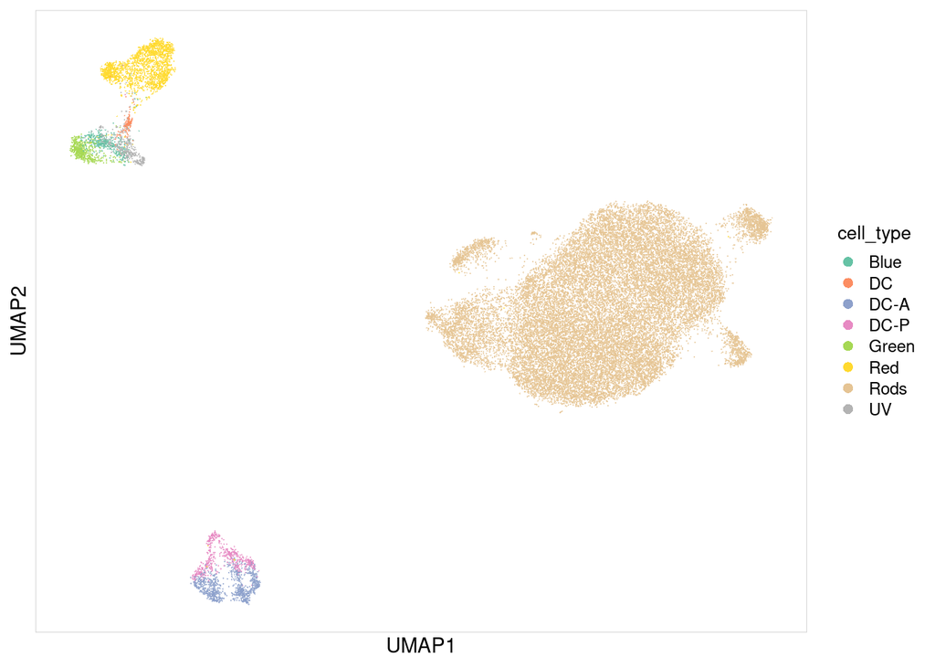

```r
scCSIobj <- CSI.run_umap(scCSIobj)
CSI.plot_umap(scCSIobj, color = "cell_type")
```

If you’d only like to plot a subset a cells, you can subset the object, then run the umap again:

```r
sub_scCSIobj <- CSI.subset_cells(scCSIobj, scCSIobj$colmetadata$cell_type != "Rods")
```

```
#> Keeping 4775 of 29814 cells.
```

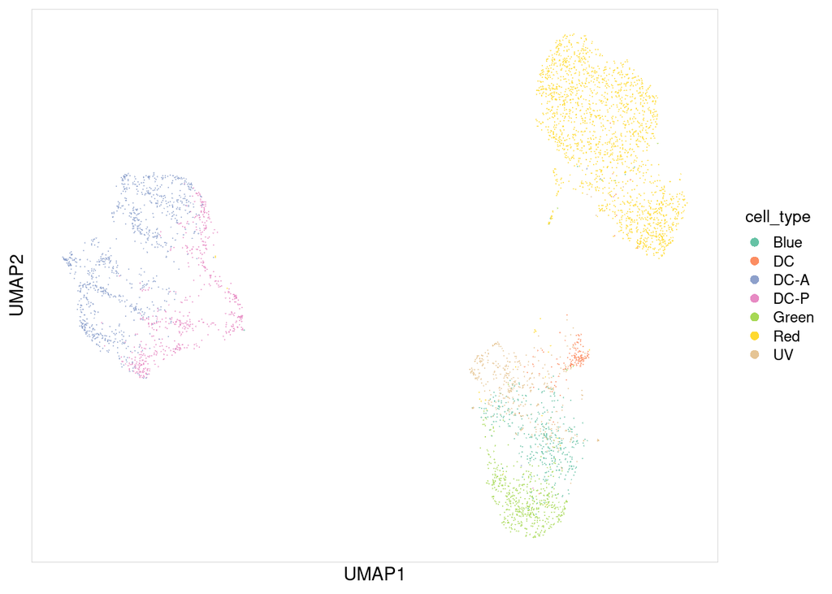

```r
sub_scCSIobj <- CSI.run_umap(sub_scCSIobj)
CSI.plot_umap(sub_scCSIobj, color = "cell_type")
```

#### Tree Heatmaps

If you want to plot the expression of genes wtihin an orthogroup, it can be done with a cluster heatmap. This series of commands clusters genes within an orthogroup using a dynamic tree cut algorithm on the Orthofinder gene trees. Then, it extracts the counts for every gene in an orthogroup.

Note that Orthofinder classifications, while accurate most of the time, are not perfect. If a gene is missclassified (i.e, a name match for a gene in another species is found in another orthogroup), genes from other, related orthogroups will be plotted as well. To disable this, these genes can be filtered out of the heat map dataframe before passing it into `CSI.plot_cluster_heatmap`

```r
OG = scCSIobj$orthogroups$Orthogroup[2500] # pick an arbitrary orthogroup for example

#this line is unneccessary, but if you'd just like the get the gene clusters, run this:
clusters = CSI.cluster_genetree(OG = OG, scCSI.obj = scCSIobj)
```

```
#>  ..cutHeight not given, setting it to 1.33  ===>  99% of the (truncated) height range in dendro.
#>  ..done.
```

```r
#to get the plot, run this
heatdf <- CSI.get_heatmap_dataframe(OG = OG, scCSI.obj = scCSIobj)
```

```
#>  ..cutHeight not given, setting it to 1.33  ===>  99% of the (truncated) height range in dendro.
#>  ..done.
```

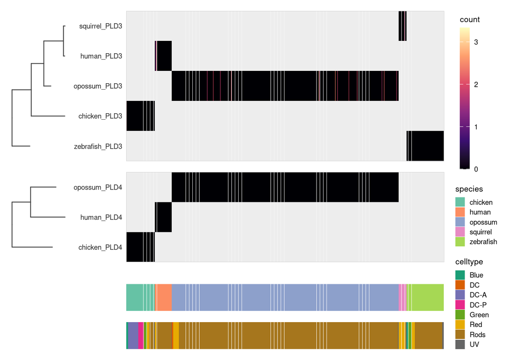

```r
p <- CSI.plot_cluster_heatmap(heatdf = heatdf, OG = OG, scCSI.obj = scCSIobj)
p
```

If you only want to look at one celltype, subset the object:

```r
scCSIobj_sub <- CSI.subset_cells(scCSIobj, scCSIobj$colmetadata$cell_type == "Red")
```

```
#> Keeping 1869 of 29814 cells.
```

```r
heatdf <- CSI.get_heatmap_dataframe(OG = OG, scCSI.obj = scCSIobj_sub)
```

```
#>  ..cutHeight not given, setting it to 1.33  ===>  99% of the (truncated) height range in dendro.
#>  ..done.
```

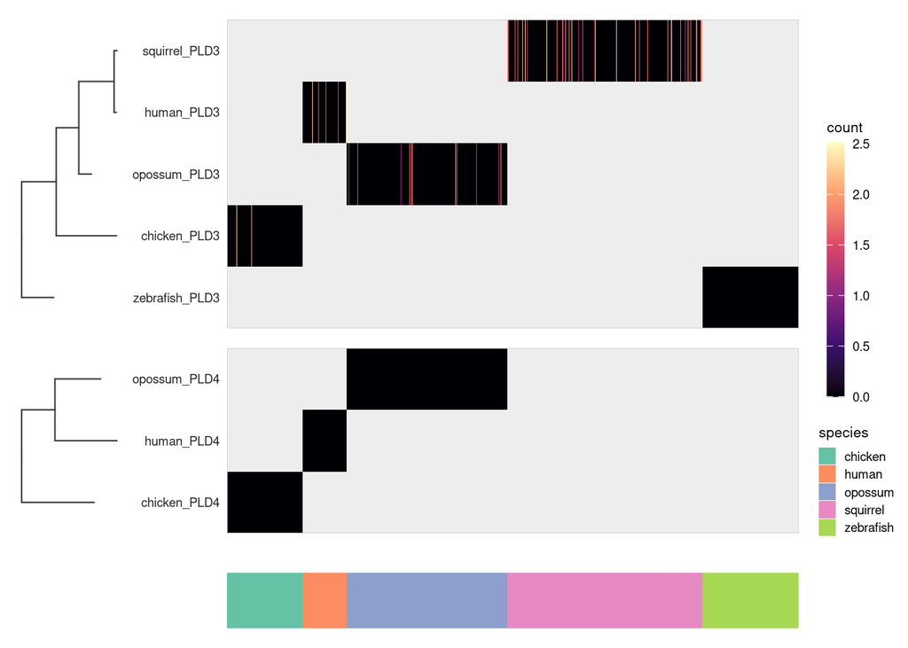

```r
p <- CSI.plot_cluster_heatmap(heatdf = heatdf, OG = OG, scCSI.obj = scCSIobj_sub, show_celltype = F)
p
```

## Gene Tree Analysis

There may be a case when you’d like to compare the expression of related genes in an orthogroup. scCSI provides a basic framework to accomplish this.

In this case, we want to examine the expression of different opsin families across different photoreceptor subtypes. To do this, we first need to retrieve all orthogroups that contain opsin genes:

```r
ogs <- scCSIobj$orthogroups

allgenes <-  c()
for(i in 1:nrow(ogs)){
  genes <- ogs[,2:ncol(ogs)][i,]
  genes <- paste(genes, collapse = ", ")
  allgenes <- c(allgenes, genes )
}
names(allgenes) <- ogs$Orthogroup

opsin_ogs <- allgenes[grep("OPN", allgenes)]
opsin_ogs <- opsin_ogs[-c(8, 12, 15)]
print(opsin_ogs)
```

```
#>                                                                                OG0000953
#>      "OPN1MSW, RHO, RHO, RHO, RHO, EXORH, OPN1MW1, OPN1MW2, OPN1MW3, OPN1MW4, RHO, RHOL"
#>                                                                                OG0002038
#> "OPN1LW, OPN1LW, OPN1MW, OPN1MW2, OPN1MW3, OPN1LW, ENSSTOG00000024701, OPN1LW1, OPN1LW2"
#>                                                                                OG0002806
#>                                           "OPN4, OPN4, OPN4, OPN4, OPN4.1, OPN4A, OPN4B"
#>                                                                                OG0005856
#>                                                "OPN1SW, OPN1SW, OPN1SW, OPN1SW, OPN1SW1"
#>                                                                                OG0005857
#>                                                           "OPN3, OPN3, OPN3, OPN3, OPN3"
#>                                                                                OG0005858
#>                                                           "OPN5, OPN5, OPN5, OPN5, OPN5"
#>                                                                                OG0005859
#>                                               "OPN5L1, , , , OPN7A, OPN7B, OPN7C, OPN7D"
#>                                                                                OG0010326
#>                                                    "LOC112531269, OPN2SW, , , , OPN1SW2"
#>                                                                                OG0010438
#>                                                           "OPN4-1, , , , OPN4XA, OPN4XB"
#>                                                                                OG0010439
#>                                                            "OPNVA, , , , VALOPA, VALOPB"
#>                                                                                OG0011284
#>                                                              "LOC100858777, , , , OPN6A"
#>                                                                                OG0011422
#>                                                                    "OPN5L2, , , , OPN8A"
```

Now, we can merge these orthogroups together and reconstruct the gene trees:

```r
scCSIobj <- CSI.merge_orthogroups(scCSIobj, names(opsin_ogs), aligner = "msa")
```

```
#> use default substitution matrix
#> Setting 1 negative branch length(s) to zero.
#> Built a tree for OG0000953 + OG0002038 + OG0002806 + OG0005856 + OG0005857 + OG0005858 + OG0005859 + OG0010326 + OG0010438 + OG0010439 + OG0011284 + OG0011422: 61 tips, chicken/human/opossum/squirrel/zebrafish, msa alignment, nj.
#> Merged 12 orthogroup(s) into OGR_1: 61 genes, 33 matrix row(s); originals removed.
```

```r
#because this is the first user-generated orthogroup, it will be stored under id "OGR_1"
```

Just for now, let’s look at the opsins that are upregulated in rods and cones.

```r
ct = "Rods"
scCSIobj_sub <- CSI.subset_cells(scCSIobj, scCSIobj$colmetadata$cell_type == ct)
```

```
#> Keeping 25039 of 29814 cells.
```

```r
de <- CSI.de_along_genetree("OGR_1", scCSIobj_sub)
```

```
#>  ..cutHeight not given, setting it to 2.21  ===>  99% of the (truncated) height range in dendro.
#>  ..done.
```

```r
de_tree <- CSI.plot_de_tree("OGR_1", scCSIobj_sub, de) + ggtitle(ct)
```

```
#>  ..cutHeight not given, setting it to 2.21  ===>  99% of the (truncated) height range in dendro.
#>  ..done.
```

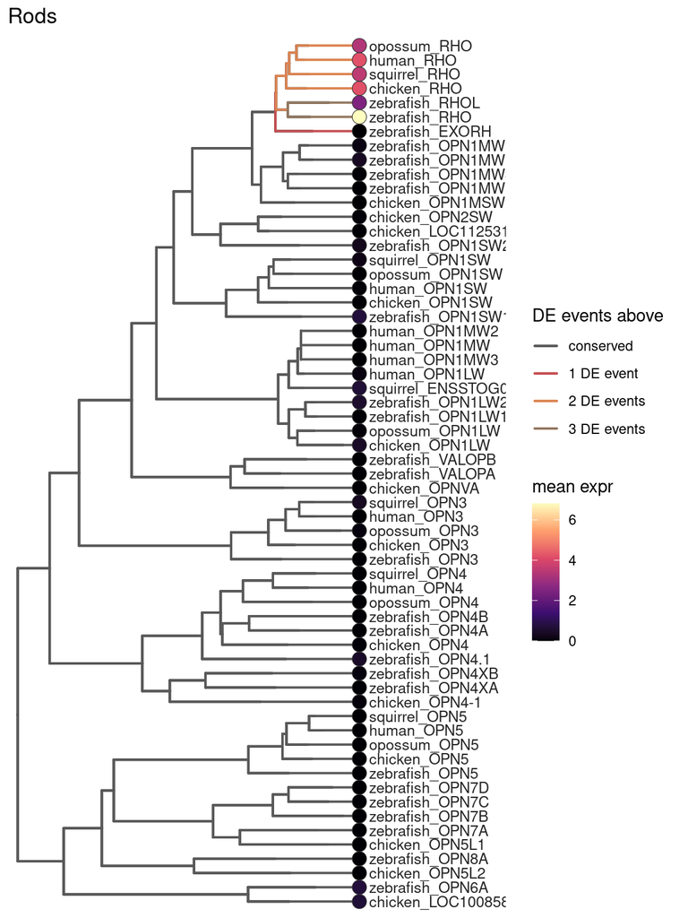

```r
de_tree
```

```r
ct = "Red"
scCSIobj_sub <- CSI.subset_cells(scCSIobj, scCSIobj$colmetadata$cell_type == ct)
```

```
#> Keeping 1869 of 29814 cells.
```

```r
de <- CSI.de_along_genetree("OGR_1", scCSIobj_sub)
```

```
#>  ..cutHeight not given, setting it to 2.21  ===>  99% of the (truncated) height range in dendro.
#>  ..done.
```

```r
de_tree <- CSI.plot_de_tree("OGR_1", scCSIobj_sub, de) + ggtitle(ct)
```

```
#>  ..cutHeight not given, setting it to 2.21  ===>  99% of the (truncated) height range in dendro.
#>  ..done.
```

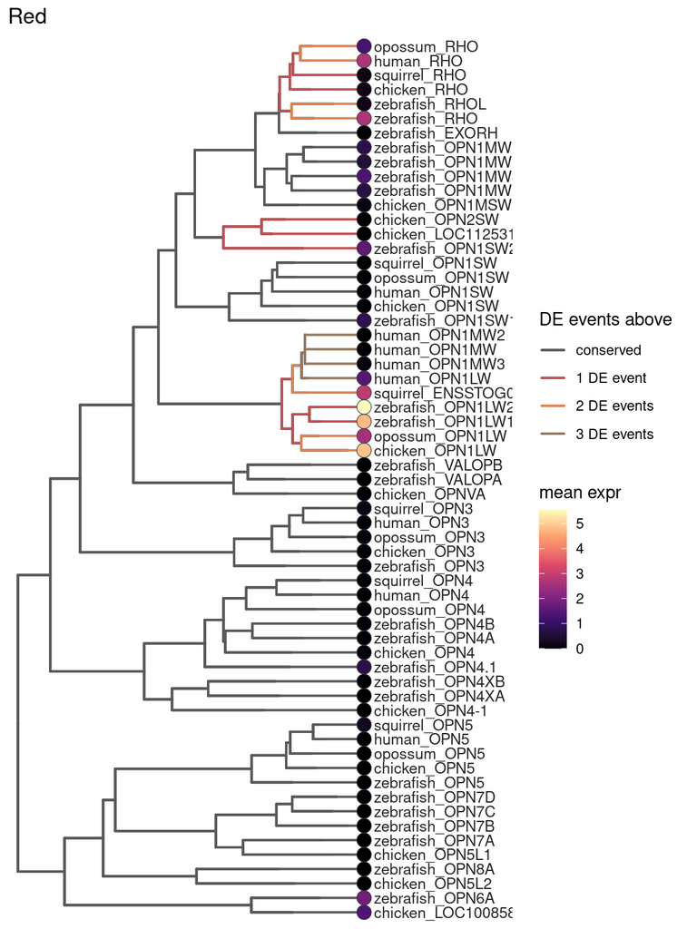

```r
de_tree
```

If you are unsure of what gene families you’d like to examine, you can run DE along all orthogroups to identify interesting candidates. Treat this as hypothesis generation, and check to see if there are related genes worth examining in other orthogroups!

```r
# run every testable orthogroup, restricted to one cell type
de_all <- CSI.de_all_orthogroups(scCSIobj, ct = "Rods", ncores = 16)
sig <- CSI.filter_divergent_orthogroups(de_all)
summary_tbl <- CSI.summarise_de(sig)
```

# The scCSI object

`CSI.load.obj()` returns a plain named list, not an S4 class, so any slot can be read or replaced directly. The functions in this package assume the slots below stay consistent with each other.

## Slots

| Slot | Indexed by | Contents |
| --- | --- | --- |
| `matrix` | rows = matrix rows, columns = cells | log-normalised sparse matrix (`dgCMatrix`). `rownames` are `rowmetadata$row_id`, `colnames` are `colmetadata$cell_id`. |
| `rowmetadata` | matrix rows | one row per matrix row, as written by `scCSIMerger`. `row_id` is the key the loader uses for `rownames(matrix)`. |
| `colmetadata` | cells | one row per cell: `cell_id`, `species`, the cell type column you named in `annotation_obs_col`. Anything else you add here is available to `CSI.plot_umap(color = ...)`. |
| `embedding` | cells | cells x dimensions matrix, row names = `cell_id`. The TPS-corrected PCA from integration, whatever `CSI.set_embedding()` put there, or `NULL`. |
| `umap` | cells | added by `CSI.run_umap()`: a data frame of `UMAP1`, `UMAP2`. Absent until you run it. |
| `genetrees` | orthogroups | named list of `phylo` objects, names are orthogroup IDs, read from OrthoFinder’s `Resolved_Gene_Trees/`. `CSI.merge_orthogroups()` appends `OGR_<n>` entries. |
| `species_tree` | — | OrthoFinder’s rooted species tree, or `NULL` if the file was absent. |
| `orthogroups` | orthogroups | OrthoFinder’s `Orthogroups.tsv`: `Orthogroup` plus one column per species. |
| `orthogroup_merges` | merges | added by `CSI.merge_orthogroups()`: `new_id`, `member`, `n_tips`. |
| `matrix.directory` | — | the `merged.dir` the object was loaded from. |
| `orthofinder.dir` | — | the OrthoFinder directory. Re-read by `CSI.build_orthogroup_tree()`, so it must still exist. |

## The three index families

Three sets of things are indexed in parallel, and each set has to stay internally aligned:

- **Cells** — `matrix` columns, `colmetadata` rows, `embedding` rows, `umap` rows. Same cells, same order.
- **Matrix rows** — `matrix` rows and `rowmetadata` rows. One row is one orthogroup layer, holding at most one gene per species.
- **Orthogroups** — `orthogroups` rows, `genetrees` names, and the orthogroup column of `rowmetadata`. Not every orthogroup has a gene tree; OrthoFinder only resolves trees for groups above a size threshold, and orthogroups with no tree are handled as a single cluster by `CSI.cluster_genetree()`.

Use `CSI.subset_cells()` rather than subsetting slots by hand. It filters every cell-indexed slot at once.

# Full Documentation

## Setup

### `CSI.install_env()`

Creates the conda environment the Python classes need, from the `environment.yml` bundled with the package.

- `envname` — name of the conda environment to create. Default `"sccsi_env"`.

Returns `TRUE`, invisibly.

```r
CSI.install_env()

# point reticulate at it before creating any wrapper object
reticulate::use_condaenv("sccsi_env", required = TRUE)
```

Reticulate binds to an interpreter the first time Python is touched and will not switch afterwards, so `use_condaenv()` must come before any `$new()` call below.

### `CSI.seurat_to_h5ad()`

Writes a Seurat object’s raw counts to h5ad for the Python side. The matrix is transposed on the way out: Seurat stores genes x cells, AnnData expects cells x genes.

- `sobj` — a Seurat object.
- `path` — output `.h5ad` path.
- `assay` — assay to pull from. `NULL` uses the default assay.
- `layer` — layer to pull. `"counts"` gives raw counts.
- `obs_columns` — `meta.data` columns to keep. `NULL` keeps all storable columns.
- `overwrite` — overwrite `path` if it exists. Default `FALSE`.

Returns `path`, invisibly.

```r
CSI.seurat_to_h5ad(sobj, "human.h5ad", overwrite = TRUE)
```

## Integration (Python wrappers)

### `OrthoFinderWrapper`

Runs OrthoFinder and reads its output.

```r
ofw <- OrthoFinderWrapper$new()
```

#### `$run_orthofinder(inputdir, orthofinder_path, threads = 16L)`

Runs OrthoFinder over a directory of proteome FASTA files. Blocks until it finishes; results are written beneath `inputdir`, not returned.

- `inputdir` — directory of proteome FASTA files to compare.
- `orthofinder_path` — path to the OrthoFinder executable.
- `threads` — threads for OrthoFinder to use. Default 16.

#### `$read_orthogroups(orthofinder_dir)`

Reads `Orthogroups.tsv` from a completed run into a data frame.

- `orthofinder_dir` — OrthoFinder output directory (the one containing an `Orthogroups/` subdirectory).

```r
ofw$run_orthofinder(
  inputdir         = "filtered_proteomes/",
  orthofinder_path = "~/bin/orthofinder",
  threads          = 16
)

ogs <- ofw$read_orthogroups("filtered_proteomes/OrthoFinder/Results_Sep15/")
```

### `scCSIPreprocess`

Prepares FASTAs and scRNA-seq data so the two agree on gene names.

```r
prep <- scCSIPreprocess$new()
```

#### `$preprocess_fasta_headers(gtf_fasta_map, out_dir)`

Renames FASTA headers from raw accessions to gene symbols. Detects RefSeq vs Ensembl (and GTF vs GFF3) per species. Writes a renamed `{species}.faa` and a `{species}_id_map.csv` for each species.

- `gtf_fasta_map` — named list, one entry per species, each an inner named list with `gtf` and `fasta` paths.
- `out_dir` — destination for the renamed FASTAs and ID maps. Required.

#### `$synchronize_scrna_and_proteomes(species_map, prot_out_dir, scrna_out_dir)`

Filters scRNA-seq and protein sequences down to shared genes. Headers are assumed to already be gene symbols; both sides are upper-cased before intersecting, so they need only agree up to case. Species with no shared genes are skipped with a warning.

- `species_map` — named list, one entry per species, each an inner named list with `h5ad` and `fasta` paths.
- `prot_out_dir` — directory for the filtered proteomes. Required.
- `scrna_out_dir` — directory for the filtered expression data. Required.

```r
prep$preprocess_fasta_headers(
  gtf_fasta_map = list(
    chicken = list(gtf = "chicken.gtf", fasta = "chicken.faa"),
    human   = list(gtf = "human.gtf",   fasta = "human.faa")
  ),
  out_dir = "renamed_proteomes/"
)

prep$synchronize_scrna_and_proteomes(
  species_map = list(
    chicken = list(h5ad = "chicken.h5ad", fasta = "renamed_proteomes/chicken.faa"),
    human   = list(h5ad = "human.h5ad",   fasta = "renamed_proteomes/human.faa")
  ),
  prot_out_dir  = "filtered_proteomes/",
  scrna_out_dir = "filtered_scrna/"
)
```

Because this step rewrites headers to bare gene symbols, the species a sequence came from is no longer recoverable from the FASTA alone. That matters later for `CSI.build_orthogroup_tree()`, which resolves species by matching sequences against OrthoFinder’s `WorkingDirectory/`.

### `scCSIMerger`

Merges per-species scRNA-seq into a joint orthogroup-layer matrix. All configuration happens at construction; `$run()` executes the pipeline.

#### `$new(...)`

- `orthofinder_resultdir` — OrthoFinder results used for orthogroup assignment.
- `scrna_dirs` — named list of scRNA-seq paths keyed by species. The names define the species set for the run.
- `output_dir` — destination for the merged matrix and metadata.
- `annotation_obs_col` — column in `adata.obs` holding cell type labels.
- `ncores` — worker processes for parallelised steps. Default 16.
- `counts_layer` — layer holding raw counts, e.g. `"counts"`. `NULL` uses `adata$X`. Set this whenever `adata$X` was normalised in place.
- `normalise` — depth-scale counts during the merge. Default `TRUE`.
- `scale_factor` — target sum per cell for depth scaling. Default `1e4`.
- `log1p` — apply `log1p` after scaling. Default `TRUE`.
- `normalise_by` — `"matrix"` (joint matrix column sums, consistent with the DE offset) or `"genome"` (each cell’s total across all genes in its original object). Default `"matrix"`.
- `layer_means_on` — basis for the cell-type means driving layer assignment: `"normalised"` or `"raw"`. Default `"normalised"`.

#### `$run()`

Runs the full pipeline and writes to `output_dir` (`matrix.mtx`, `matrix_normalised.mtx`, `metadata.txt`, `rowmetadata.csv`, `barcodes.tsv`, `features.tsv`, `normalisation.json`).

```r
merger <- scCSIMerger$new(
  orthofinder_resultdir = "filtered_proteomes/OrthoFinder/Results_Sep15/",
  scrna_dirs            = list(chicken = "filtered_scrna/chicken.h5ad",
                               human   = "filtered_scrna/human.h5ad"),
  output_dir            = "merged_output/",
  annotation_obs_col    = "cell_type",
  ncores                = 16
)

merger$run()
```

### `scCSIIntegration`

Integrates species on the merged matrix: feature selection, PCA, then a thin-plate-spline warp across species.

All AnnData objects here are live Python references (reticulate proxies). Pass them straight back into subsequent calls rather than inspecting them as R objects.

```r
integ <- scCSIIntegration$new(output_dir = "merged_output/")
```

- `output_dir` — directory the merged matrices were written to by `scCSIMerger`.
- `reference_species` — species ID to correct towards. `NULL` picks the species with the most cells during `prepare_for_integration()`.

#### `$load()`

Re-loads `matrix.mtx`, `metadata.txt` and `rowmetadata.csv` from `output_dir`, then computes per-cell-type means.

#### `$select_features(discriminability_threshold = 0.75, conservation_threshold = 0.5)`

Selects features both conserved across species and discriminative between cell types. Conservation is scored first and filters the candidate pool; the discriminability cutoff is a percentile of the survivors only.

- `discriminability_threshold` — percentile cutoff as a fraction (`0.75` keeps the most variable quarter; `0.0` keeps all).
- `conservation_threshold` — minimum mean pairwise Spearman correlation across species, in `[-1, 1]`.

#### `$to_anndata()`

Converts the feature-by-cell matrix into a cell-by-feature AnnData, sliced to the selected features. Requires `$select_features()` first.

#### `$prepare_for_integration(n_components = 50L)`

Builds the AnnData and PCA embedding consumed by `$integrate()`. Normalises to 10,000 counts/cell, `log1p`, unit scaling clipped at 10 SD, then PCA. Also classifies cell types as a side effect.

- `n_components` — principal components to compute. Must not exceed `min(n_cells, n_features)`.

#### `$integrate(adata_pca, ...)`

Optimises `n_anchors_target` via Optuna, then refits and applies the correction with the winning parameters. Requires the `scib` Python package.

- `adata_pca` — AnnData from `$prepare_for_integration()`, carrying `obsm["X_pca"]`, `obs["species"]` and `obs["cell_type"]`. Modified in place.
- `n_trials` — Optuna trials. Default 10.
- `n_jobs` — trials run concurrently. Default 1.
- `random_state` — seed for the TPE sampler, neighbour graph and Leiden. Default 42.
- `metric_weights` — named list keyed by `"ari"`, `"nmi"`, `"graph_connectivity"`, normalised to sum to one.
- `regularisation` — ridge term on the TPS kernel diagonal. Default 1.0.
- `cell_type_agnostic` — match anchors across the whole species pair rather than within shared cell types. Default `FALSE`.
- `min_anchor_weight` — minimum rank correlation for a candidate pair to be kept. Default 0.3.
- `save` — write the corrected AnnData to `output_dir`. Default `TRUE`.
- `prefix` — filename stem used when `save` is `TRUE`. Default `"integrated"`.

Returns a length-3 list: `adata`, `study`, `best_params`.

#### `$integrate_no_optimization(adata, ...)`

The fixed-parameter counterpart: anchor selection and TPS correction once, with no Optuna search.

- `nanchors` — anchors per species pair. Default 1000.
- `X_ranked` — precomputed rank-transformed embedding, or `NULL`.
- `chunk_size` — row block size for the correlation matrix product. Default 512.
- `save`, `prefix` — as for `$integrate()`.

Other arguments as for `$integrate()`. Returns the corrected AnnData.

#### `$post_integration_correction(adata, group_cols, ...)`

Removes outlier cells per group using robust Mahalanobis distance (MCD) on PCA or UMAP coordinates. Only run if needed, after integration.

- `group_cols` — `.obs` columns to group by, e.g. `c("species", "cell_type")`.
- `method` — `"pca"` uses `obsm["X_pca"]`; `"umap"` generates a UMAP first. Default `"pca"`.
- `pval_cutoff` — chi-squared threshold; cells below are removed. Default 0.01.
- `n_neighbors`, `min_dist`, `random_state` — UMAP only.
- `save` — write the filtered AnnData, replacing the file the integration step wrote. Default `TRUE`.
- `prefix` — filename stem. Leave at the default to overwrite the integration output; change it to keep both versions.

#### `$save_results(adata, prefix = "integrated", output_dir = NULL, overwrite = TRUE)`

Writes an AnnData to `output_dir`. Called automatically by the three methods above; call it directly only to write an object again or under a different name.

```r
integ$load()
integ$select_features(discriminability_threshold = 0.75,
                      conservation_threshold     = 0.5)

adata_pca <- integ$prepare_for_integration(n_components = 50)

# writes merged_output/integrated.h5ad
res <- integ$integrate(adata_pca, n_trials = 20)
res$best_params

# replaces merged_output/integrated.h5ad with the filtered version
integ$post_integration_correction(res$adata,
                                  group_cols = c("species", "cell_type"))
```

Because both steps default to `prefix = "integrated"`, `output_dir` always holds the most corrected version. Pass a different `prefix` to the correction step to keep both.

## Downstream Analysis Utilities

### `CSI.load.obj()`

Loads a merged run into a single list used by everything below.

- `merged.dir` — directory containing the merged output from the integration module.
- `orthofinder.dir` — the OrthoFinder directory generated by scCSI.
- `integrated` — file name of the integrated h5ad within `merged.dir`. Default `"integrated.h5ad"`. Change this if you saved with a different `prefix`. `NULL` skips the integration output entirely and loads the merged data alone.
- `require.integrated` — error when `integrated` is named but missing. Default `FALSE`, which warns and loads the merged data with a `NULL` embedding. Set `TRUE` in scripts where a silently un-integrated object would be a bug.
- `obsm.key` — key in `adata$obsm` holding the corrected embedding. Default `"X_pca_tps"`.

Returns a list with `matrix` (normalised), `rowmetadata`, `colmetadata`, `embedding`, `genetrees`, `species_tree`, `orthogroups`, and the two source directories. `embedding` is `NULL` when no integration output was loaded. `species_tree` is OrthoFinder’s rooted species tree, or `NULL` if the file is absent.

```r
obj <- CSI.load.obj(
  merged.dir      = "merged_output/",
  orthofinder.dir = "filtered_proteomes/OrthoFinder/Results_Sep15/"
)

# merged matrix only
obj <- CSI.load.obj(
  merged.dir      = "merged_output/",
  orthofinder.dir = "filtered_proteomes/OrthoFinder/Results_Sep15/",
  integrated      = NULL
)
```

### `CSI.set_embedding()`

Replaces `$embedding` with coordinates of your own, and aligns every cell-indexed slot to them. Use it when you have integrated with another method, want a plain PCA of the merged matrix as a baseline, or loaded with `integrated = NULL` and now need the embedding-based functions.

- `scCSI.obj` — object from `CSI.load.obj()`.
- `embedding` — a numeric matrix or data frame of cells x dimensions, or a path to a `.csv`/`.tsv` (cell ids in the first column) or a `.h5ad`.
- `cells` — optional character vector of cell ids, one per row of `embedding`, for embeddings that carry no row names.
- `obsm.key` — key in `adata$obsm` to read when `embedding` is a path to an h5ad. Default `"X_pca"`.
- `subset` — drop cells missing from the embedding. Default `TRUE`. `FALSE` errors instead, so a partial embedding cannot quietly shrink the object.
- `drop.umap` — remove the existing `$umap`, which no longer matches the new coordinates. Default `TRUE`.

Returns the object with `$embedding` replaced.

```r
obj <- CSI.set_embedding(obj, harmony_mat)
obj <- CSI.set_embedding(obj, "scanvi.h5ad", obsm.key = "X_scANVI")
obj <- CSI.set_embedding(obj, "coords.csv", subset = FALSE)

obj <- CSI.run_umap(obj)
CSI.plot_umap(obj, color = "species")
```

Cells are matched by name, never by position. Cells in the object but not in the embedding are dropped with a message; cells in the embedding but not in `colmetadata` are discarded with a warning. An embedding with no row names is accepted only if it has exactly one row per cell, and is then assumed to be in `colmetadata` order — a warning says so, because a wrong guess there is silent and total. Supply `cells` instead if you can.

The counts are untouched, so a swapped embedding changes the UMAP and the cell type trees but not the heatmaps or the DE results.

### `CSI.subset_cells()`

Filters every cell-indexed slot at once: matrix columns, `colmetadata` rows, and the `embedding` and `umap` coordinates where present. Gene-indexed slots are untouched.

- `scCSI.obj` — object from `CSI.load.obj()`.
- `cells` — logical vector, one element per row of `colmetadata`, `TRUE` to keep. A character vector of `cell_id`s also works.

```r
obj_red <- CSI.subset_cells(obj, obj$colmetadata$cell_type == "Red")
obj_two <- CSI.subset_cells(obj, obj$colmetadata$species %in% c("human", "squirrel"))
```

The `umap` slot is carried through as-is, so points keep their original positions. To recompute the layout on just the retained cells, drop it first with `obj$umap <- NULL` and re-run `CSI.run_umap()`.

### `CSI.cluster_genetree()`

Dynamic tree cut of one orthogroup’s gene tree using dynamicTreeCut .

- `OG` — orthogroup ID, e.g. `"OG0009996"`.
- `scCSI.obj` — object from `CSI.load.obj()`.
- `hclust.method` — linkage passed to `hclust()`. Default `"average"`.
- `cut.method`, `minClusterSize`, `deepSplit` — passed to `dynamicTreeCut::cutreeDynamic()`.

Returns a data frame with `tip`, `cluster`, `species`, `gene`. Trees with fewer than three tips are returned as a single cluster.

```r
clusters <- CSI.cluster_genetree("OG0009996", obj)
head(clusters)
```

### `CSI.get_heatmap_dataframe()`

Builds the long data frame the heatmap consumes.

- `OG` — orthogroup ID of interest.
- `scCSI.obj` — object from `CSI.load.obj()`.
- `ct` — cell type(s) to keep. `NULL` keeps all.
- `...` — passed to `CSI.cluster_genetree()`.

Returns a data frame with `cell_id`, `species`, `celltype`, `count`, `gene`, `genecluster`. Numeric-looking `genecluster` values came from the tree cut; the rest are orthogroup IDs for genes OrthoFinder placed outside this tree.

```r
heatdf <- CSI.get_heatmap_dataframe("OG0009996", obj, ct = "Red")
head(heatdf)
```

Species with no gene in an orthogroup appear as `species_NA`. These are expected absences and are not warned about; genuinely unresolvable genes still are.

### `CSI.plot_cluster_heatmap()`

Gene-by-cell heatmap stacked in one column, one row per gene cluster, with a dendrogram beside clusters that came from the tree and nothing beside those that did not. Species and cell type colour bars run along the bottom.

- `heatdf` — data frame from `CSI.get_heatmap_dataframe()`.
- `OG` — orthogroup ID; the tree is pulled from `scCSI.obj$genetrees[[OG]]`.
- `scCSI.obj` — object from `CSI.load.obj()`.
- `tree` — optional tree overriding the lookup. Mostly for testing.
- `fill_colours` — colours for the count scale, low to high. `NULL` uses viridis.
- `fill_option`, `fill_direction` — viridis option and direction, used only when `fill_colours` is `NULL`. `direction = 1` runs dark to light.
- `na_colour` — colour for cell x gene combinations with no data.
- `species_colours` — colours for the species bar, named by species or unnamed in alphabetical order.
- `species_palette` — brewer palette, used when `species_colours` is `NULL`. Default `"Set2"`.
- `celltype_colours` — colours for the cell type bar, named by cell type or unnamed in alphabetical order.
- `celltype_palette` — brewer palette, used when `celltype_colours` is `NULL`. Default `"Dark2"`.
- `show_celltype` — draw the cell type bar. Default `TRUE`.
- `cell_order` — columns to sort cells by. Default `c("species", "celltype", "cell_id")`.
- `tree_width` — dendrogram column width relative to the heatmap.
- `bar_height` — height of each annotation bar, in units of one gene row.
- `base_size` — base font size.
- `panel_fill` — background colour behind the tiles.

Returns a patchwork object.

```r
CSI.plot_cluster_heatmap(heatdf, "OG0009996", obj)

# species bar only
CSI.plot_cluster_heatmap(heatdf, "OG0009996", obj, show_celltype = FALSE)

# custom colours
CSI.plot_cluster_heatmap(
  heatdf, "OG0009996", obj,
  fill_colours     = c("#0d0887", "#cc4778", "#f0f921"),
  species_colours  = c(human = "#4C72B0", chicken = "#C44E52"),
  celltype_colours = c(Red = "#C44E52", Blue = "#4C72B0")
)
```

Brewer palettes cap at 8–12 levels, so pass explicit colours for high-cardinality columns.

## UMAP

### `CSI.run_umap()`

Computes a UMAP from the integrated embedding and stores it on the object.

- `scCSI.obj` — object carrying `$embedding` (the TPS-corrected PCA).
- `n_neighbors`, `min_dist`, `metric` — passed to `uwot::umap()`.
- `seed` — random seed for reproducible coordinates. `NULL` to skip.
- `...` — further arguments passed to `uwot::umap()`.

Returns the object with a `$umap` data frame added (`UMAP1`, `UMAP2`).

```r
obj <- CSI.run_umap(obj)
obj <- CSI.run_umap(obj, n_neighbors = 30, min_dist = 0.3)
```

### `CSI.plot_umap()`

Scatter plot of the UMAP, coloured by any column of `colmetadata`.

- `scCSI.obj` — object with a `$umap` slot, from `CSI.run_umap()`.
- `color` — column of `colmetadata` to colour by. Default `"cell_type"`.
- `cols` — optional colours. Discrete columns take a named vector (names = levels) or an unnamed vector in sorted level order; numeric columns take a gradient to interpolate.
- `palette` — brewer palette for discrete columns when `cols` is `NULL`.
- `point_size`, `alpha` — point aesthetics.
- `label` — for discrete columns, draw the level name at each group’s median position. Default `FALSE`.
- `base_size` — base font size.

Returns a ggplot object. Numeric columns get a continuous scale automatically; everything else is treated as discrete.

```r
CSI.plot_umap(obj, color = "cell_type")
CSI.plot_umap(obj, color = "species", cols = c(human = "#4C72B0", chicken = "#C44E52"))
CSI.plot_umap(obj, color = "cell_type", label = TRUE)
```

### `CSI.plot_feature()`

Seurat-style feature plot of an orthogroup’s expression on the UMAP. Counts come from `CSI.get_heatmap_dataframe()`, so the values match the heatmap and DE tree.

- `OG` — orthogroup ID.
- `scCSI.obj` — object with a `$umap` slot, from `CSI.run_umap()`.
- `mode` — `"summed"` draws one panel coloured by the summed count of every gene in the orthogroup; `"species"` draws the same value split into one panel per species; `"genes"` draws one panel per gene, titled `species_gene`. Default `"summed"`.
- `heatdf` — optional data frame from `CSI.get_heatmap_dataframe()`. Built internally if `NULL`.
- `genes` — optional vector restricting which genes are used, matched against either `gene` or `species_gene`.
- `cols` — optional gradient, low to high. `NULL` uses light grey to blue.
- `na_colour` — colour for zero-count cells, and for background cells in `"species"` mode.
- `scale_limits` — `"shared"` puts every panel on one scale; `"free"` gives each its own. Ignored in `"summed"` mode.
- `split_by` — column of `colmetadata` to split on in `"species"` mode. Default `"species"`.
- `background` — draw the other panels’ cells in grey behind each split panel. Default `TRUE`.
- `order` — draw high-expressing cells last. Default `TRUE`.
- `point_size`, `alpha` — point aesthetics.
- `ncol` — columns in the panel grid. `NULL` picks a roughly square layout.
- `combine` — `FALSE` returns the named list of ggplots instead of a patchwork.
- `base_size` — base font size.

Returns a ggplot object in `"summed"` mode, otherwise a patchwork (or a named list if `combine = FALSE`). Cells absent from `heatdf` are drawn at zero rather than dropped, so every panel shows the full UMAP.

```r
CSI.plot_feature("OG0009996", obj)
CSI.plot_feature("OG0009996", obj, mode = "species")
CSI.plot_feature("OG0009996", obj, mode = "genes", ncol = 4)
CSI.plot_feature("OG0009996", obj, mode = "genes", scale_limits = "free")
```

## Orthogroup refactoring

OrthoFinder sometimes splits a single gene family across several orthogroups. These two functions let you identify those cases yourself and merge them back together.

### `CSI.build_orthogroup_tree()`

Reads the protein FASTA(s) OrthoFinder wrote for one or more orthogroups, aligns them together, and infers a tree. Passing several orthogroups aligns all their sequences as one set, which is how `CSI.merge_orthogroups()` builds the tree for a merged group.

- `scCSI.obj` — object from `CSI.load.obj()`. Supplies `$orthofinder.dir`, and `$orthogroups` for species assignment.
- `orthogroups` — character vector of orthogroup IDs. Sequences from all of them are pooled into a single alignment.
- `aligner` — `"DECIPHER"` (default) uses `DECIPHER::AlignSeqs()`; `"msa"` uses `msa::msa()`; `"none"` assumes the sequences are already aligned and equal length.
- `tree_method` — `"nj"` (default) neighbour joining, `"upgma"` for an ultrametric tree, or `"ml"` to optimise the NJ tree under maximum likelihood. `"ml"` is far slower and only worth it for small orthogroups.
- `model` — amino acid substitution model passed to `phangorn::dist.ml()`. Default `"JTT"`.
- `root` — `"midpoint"` (default) midpoint-roots the tree, which NJ leaves unrooted; `"none"` returns it as inferred.
- `clamp_negative` — set negative branch lengths, which NJ can produce, to zero. Default `TRUE`, because `CSI.cluster_genetree()` assumes non-negative branches.
- `on_unresolved` — sequences whose species cannot be determined: `"drop"` (default) leaves them out of the alignment, `"keep"` gives them a bare gene symbol as a tip label.
- `verbose` — let the aligner print its progress. Default `FALSE`.

Returns a phylo object, ladderized, with tips `"species_gene"`.

```r
tr <- CSI.build_orthogroup_tree(obj, "OG0009996")
tr <- CSI.build_orthogroup_tree(obj, c("OG0009996", "OG0010233"),
                                tree_method = "upgma")
```

Species are recovered by matching each record against the per-species proteomes in OrthoFinder’s `WorkingDirectory/`, because headers renamed to gene symbols no longer carry the species themselves. Tips that end up without a species prefix do not match the expression data, which is why they are dropped by default. If `WorkingDirectory/` is absent from your results, species can only be guessed from gene symbols, and any symbol shared across species is ambiguous — you will get a warning saying so.

Requires `Biostrings`, `phangorn`, and one of `DECIPHER` or `msa`. These are suggested rather than required dependencies, so install them before merging.

### `CSI.merge_orthogroups()`

Combines the orthogroups you identify into a new group, labelled `"OGR_<n>"` (R for refactored) and appended to the end of every orthogroup-indexed slot, then reconstructs its gene tree from the pooled protein sequences.

- `scCSI.obj` — object from `CSI.load.obj()`.
- `orthogroups` — character vector of at least two orthogroup IDs to merge. Merged IDs (`"OGR_*"`) are accepted, so merges can be built up incrementally.
- `id` — optional ID for the result. `NULL` (default) takes the next free `"OGR_<n>"`.
- `remove_originals` — drop the constituent orthogroups from `$orthogroups`, `$genetrees`, `$rowmetadata` and `$matrix`. Default `TRUE`, because leaving them in means every downstream analysis tests the same genes twice.
- `...` — passed to `CSI.build_orthogroup_tree()`.

Returns the object with the merged orthogroup appended, plus a record in `$orthogroup_merges` (a data frame of `new_id`, `member`, `n_tips`) tracking what came from where.

```r
obj <- CSI.merge_orthogroups(obj, c("OG0009996", "OG0010233"))
obj <- CSI.merge_orthogroups(obj, c("OG0004411", "OG0004512"),
                             tree_method = "upgma")
tail(obj$orthogroup_merges)

CSI.plot_de_tree("OGR_1", obj, de)
```

The expression rows are carried over unchanged: each merged orthogroup keeps its original layers, re-identified under the new ID. Genes are *not* re-assigned to layers — that assignment was made by the Python merger from cell-type mean profiles, and redoing it would mean re-running the merge step. In practice a merged orthogroup has more layers than a native one, each still holding at most one gene per species.

The merged tree comes from a fresh alignment, so its branch lengths are on a different scale from OrthoFinder’s `Resolved_Gene_Trees`. That is fine for the DE walk, which only uses topology and within-tree distances, but do not compare branch lengths between a merged tree and a native one.

## Differential expression

### `CSI.de_along_genetree()`

Within each gene cluster from the dynamic tree cut, walks the subtree from its leaves upward, testing sister profiles at every internal node with a Wilcoxon rank-sum test. Profiles are never pooled: one child continues upward, the one with the smaller KS distance to the clade this node will be compared against next. Every test is one gene against one gene. Clusters with no tree are handled by testing each gene against the pooled remainder of its cluster; clusters of a single gene are skipped.

- `OG` — orthogroup ID.
- `scCSI.obj` — object from `CSI.load.obj()`.
- `ct` — cell type(s) to restrict the analysis to. `NULL` uses all. Applied whether `heatdf` is supplied or built internally.
- `heatdf` — optional data frame from `CSI.get_heatmap_dataframe()`. Built internally if `NULL`.
- `p_threshold` — adjusted-p cutoff for calling divergence. Default 0.05.
- `lfc_threshold` — absolute log2 fold change cutoff. Default 2, i.e. a four-fold change. Seurat’s comparable default is 0.25.
- `p_adjust_method` — passed to `stats::p.adjust()`. Default `"BH"`.
- `pseudocount` — added inside the fold change. Default 1.

Returns a data frame, one row per test: `orthogroup`, `genecluster`, `mode`, `node`, `comparison`, `group1`, `group2`, `clade1`, `clade2`, `n1`, `n2`, `lfc`, `p`, `p_adj`, `diverged`, `ks1`, `ks2`, `propagated`. `group1`/`group2` are the two genes compared; `clade1`/`clade2` the clades they came from; `propagated` the gene carried upward; `ks1`/`ks2` each child’s KS distance to the reference clade.

```r
de <- CSI.de_along_genetree("OGR_1", obj, ct = "Red")
head(de)
```

### `CSI.de_all_orthogroups()`

Runs `CSI.de_along_genetree()` over many orthogroups in parallel and combines the results. P values are re-adjusted across the whole run, since per-orthogroup correction does not control the genome-wide false discovery rate.

- `scCSI.obj` — object from `CSI.load.obj()`.
- `ct` — cell type(s) to restrict the analysis to. `NULL` uses all.
- `orthogroups` — character vector of orthogroup IDs. `NULL` runs every orthogroup with at least two genes.
- `ncores` — worker processes. Default: all but one.
- `chunk_size` — orthogroups per task. Larger chunks mean less fork overhead; smaller ones balance better when orthogroups vary a lot in size. Default 50.
- `p_threshold`, `lfc_threshold` — divergence cutoffs, applied to the genome-wide adjusted p value. Defaults 0.05 and 2.
- `p_adjust_method` — passed to `stats::p.adjust()`. Default `"BH"`.
- `...` — further arguments passed to `CSI.de_along_genetree()`.

Returns a list with `results` (the combined data frame, where `p_adj` and `diverged` are genome-wide and `p_adj_og` is the per-orthogroup adjustment), `errors` (a named character vector of orthogroups that failed, with their messages), and `warnings` (a named list per orthogroup).

```r
de_all <- CSI.de_all_orthogroups(obj, ct = "Red", ncores = 8)
nrow(de_all$results)
de_all$errors
```

Parallelism uses forked workers (`parallel::mclapply`), which share the object copy-on-write rather than copying it per worker. Linux and macOS only; on Windows it falls back to one core with a warning. A single bad orthogroup cannot take down a worker — errors are captured per orthogroup and reported in `$errors`.

### `CSI.filter_divergent_orthogroups()`

Filters DE results to orthogroups containing at least one significant test, retaining every row from those orthogroups — including the non-significant ones — so each divergence can be read in the context of the conserved nodes around it.

- `de` — output of `CSI.de_all_orthogroups()` (the list, or its `$results`) or of `CSI.de_along_genetree()`.
- `by` — grouping to filter at. `"orthogroup"` (default) keeps whole orthogroups; `"genecluster"` keeps only the gene clusters that diverged, dropping quiet clusters within the same orthogroup.
- `p_threshold`, `lfc_threshold` — optional. If supplied, significance is recomputed from `p_adj` and `lfc` with these cutoffs instead of using the existing `diverged` column.

Returns a data frame of the retained rows, ordered by orthogroup and gene cluster.

```r
sig <- CSI.filter_divergent_orthogroups(de_all)
sig <- CSI.filter_divergent_orthogroups(de_all, by = "genecluster",
                                        lfc_threshold = 3)
```

### `CSI.summarise_de()`

Collapses DE results to a compact table: the orthogroup, the unique gene names it covers (species prefix stripped), its smallest adjusted p value, and its largest-magnitude log2 fold change.

- `de` — output of `CSI.de_all_orthogroups()` (the list or its `$results`), `CSI.de_along_genetree()`, or `CSI.filter_divergent_orthogroups()`.
- `sep` — separator used to flatten the gene names. Default `", "`.

Returns a data frame with `orthogroup`, `genes`, `min_p_adj`, `max_lfc`. `max_lfc` keeps its sign: it is the fold change with the largest absolute value, so a strong down-regulation is not hidden behind a weak up-regulation.

```r
head(CSI.summarise_de(de_all))
```

### `CSI.plot_de_tree()`

- `OG` — orthogroup ID.
- `scCSI.obj` — object from `CSI.load.obj()`.
- `de` — DE results: the list from `CSI.de_all_orthogroups()`, its `$results`, or the output of `CSI.de_along_genetree()`.
- `ct` — cell type to show expression for. A single type is the intended use; several are averaged together.
- `heatdf` — optional data frame from `CSI.get_heatmap_dataframe()`. Built internally if `NULL`.
- `genecluster` — optional cluster ID. `NULL` draws the whole orthogroup tree; otherwise the tree is cut down to that cluster.
- `expression_colours` — gradient for the tip dots, low to high. `NULL` uses viridis.
- `conserved_colour` — colour for branches with no DE event above them.
- `divergent_colour` — colour of the first DE level, used to seed the default palette when `divergent_colours` is `NULL`.
- `divergent_colours` — optional colours for DE levels 1, 2, 3, … in order. Interpolated if the tree nests deeper than the vector supplied.
- `max_depth` — optional cap on the number of DE levels shown. Deeper branches are folded into the last level, keeping the legend readable on heavily nested trees. `NULL` (default) shows every level.
- `point_size`, `branch_width` — drawing sizes.
- `dot_gap` — where the dot column sits, as a fraction of tree width beyond the deepest tip. Default 0.05.
- `label_offset` — gap between the dot column and the tip labels, as a fraction of tree width. Default 0.03.
- `label_space` — panel width reserved to the right of the dot column for tip labels. Raise it if long labels are clipped. Default 0.45.
- `base_size` — base font size.

Returns a ggtree (ggplot) object.

```r
CSI.plot_de_tree("OGR_1", obj, de, ct = "Red")

# one cluster only, with a custom colour ramp
CSI.plot_de_tree("OGR_1", obj, de, ct = "Red",
                 genecluster       = 1,
                 divergent_colours = c("#C44E52", "#8172B3", "#4C72B0"))
```

Divergent nodes are located by the MRCA of the tested clades rather than by node label, since `drop.tip` renumbers nodes. For a multifurcation this means every significant child collapses to the same node, so the whole multifurcation shifts colour rather than just the divergent child.

## Cell type trees

### `CSI.build_celltype_tree()`

Builds a hierarchical tree from group centroids in the integrated embedding. `CSI.build_constrained_tree()` uses this with `by = "celltype"` to infer its cell type backbone — centroids pooled across every species — before grafting the known species phylogeny onto it. Called directly with `by = "species_celltype"` it instead gives a fully data-driven tree at the same tip resolution as the constrained tree, which is useful as a sanity check against the constrained result.

- `scCSI.obj` — object from `CSI.load.obj()`. Must carry `$embedding` and `$colmetadata`.
- `by` — grouping to build tips from. `"celltype"` (default) pools cells across every species into one centroid per cell type; `"species_celltype"` keeps them separate.
- `n_dims` — embedding dimensions to use. Capped at `ncol(scCSI.obj$embedding)` if larger. Default 30.
- `dist_method` — distance between centroids: `"euclidean"` (default) on the raw centroids, or `"pearson"`/`"spearman"` using 1 − correlation.
- `hclust_method` — linkage passed to `stats::hclust()`. Default `"average"`.
- `min_cells` — groups with fewer cells than this are dropped before clustering, with a message. Default 20.
- `outgroup` — optional tip label (or vector) to root on. `NULL` (default) leaves the tree rooted at the last merge, with no particular biological meaning to that root.

Returns a list with `tree` (phylo), `centroids`, `dist`, `group` (the grouping vector actually used, one entry per cell), and `dropped`.

```r
# the backbone CSI.build_constrained_tree() itself builds internally
bb <- CSI.build_celltype_tree(obj, by = "celltype")

# a fully data-driven comparison at species x celltype resolution
sc <- CSI.build_celltype_tree(obj, by = "species_celltype")
CSI.plot_celltype_tree(sc)
```

### `CSI.build_constrained_tree()`

Infers (or accepts) a backbone tree of cell types, then grafts a copy of the known species phylogeny at every cell type tip. Tips of the result are `"species_celltype"`, matching the rest of the package.

- `scCSI.obj` — object from `CSI.load.obj()`. Must carry `$embedding`. Ignored if `celltype_tree` is supplied.
- `species_tree` — the species phylogeny, as a phylo object or a Newick string. Defaults to `scCSI.obj$species_tree`, OrthoFinder’s rooted species tree. Tip labels must match the species values in `colmetadata`.
- `celltype_tree` — optional cell type backbone, as phylo or Newick. `NULL` infers it from the embedding by clustering cell type centroids pooled across species.
- `species_depth` — height of each grafted species subtree, as a fraction of the backbone’s total height. Keeps species divergence visually and numerically subordinate to cell type divergence. Default 0.3.
- `n_dims`, `dist_method`, `hclust_method`, `min_cells` — passed through to the backbone inference when `celltype_tree` is `NULL`.

Returns a list with `tree` (phylo, tips `"species_celltype"`), `celltype_tree` (the backbone used), and `species_tree` (as rescaled and grafted).

```r
ct_tree <- CSI.build_constrained_tree(obj)
CSI.plot_celltype_tree(ct_tree)

# supply your own backbone if the tissue's cell type relationships are known
ct_tree <- CSI.build_constrained_tree(
  obj,
  celltype_tree = "((Rods,Red),(Blue,Green));"
)
```

The point is to stop the data deciding things already known. Species relationships are established; letting expression distances reorder them introduces error into every ancestral reconstruction that follows. Only the cell type backbone is inferred, and even that can be supplied.

Note that `species_depth` is a cosmetic rescaling, so branch lengths in the result are not evolutionary time. Any method that reads them quantitatively is partly reading that parameter.

### `CSI.plot_celltype_tree()`

Draws a cell type tree with coloured tip points and labels.

- `ct_tree` — output of `CSI.build_celltype_tree()` or `CSI.build_constrained_tree()`.
- `colour_by` — `"cell_type"` (default) or `"species"`. Both are parsed from the `"species_celltype"` tip labels.
- `palette` — brewer palette for the tip colours. Default `"Set2"`.
- `base_size` — base font size.
- `label_space` — room reserved to the right of the tree for tip labels, as a fraction of tree width. This is what keeps the labels — and the legend, which sits just past them — from overlapping. Raise it if long labels are still clipped or crowd the legend. Default 0.3.

Returns a ggtree (ggplot) object.

```r
CSI.plot_celltype_tree(ct_tree)
CSI.plot_celltype_tree(ct_tree, colour_by = "species", label_space = 0.5)
```